# Time Series Anlaysis. Practica 4. Discrete valued time series

Miguel Albertí Pons, Iker González Cuellar, Pol Martínez Collado

15-02-23

```r
library(dplyr)
library(tidyr)
library(reshape2)
library(magrittr)
library(stringr)
library(astsa)
library(tscount)
```

# **Exercise 1:**

**Plot the time series, its ACF and its PACF**

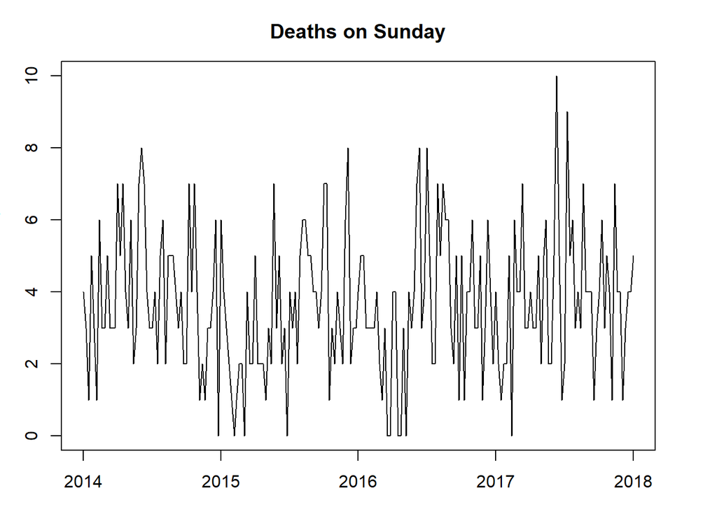

```r
load("_repository/AccidSunday.Rdata")

par(mfrow = c(1,1), mar = c(rep(3,4)))
plot(deaths.Sunday.ts, main='Deaths on Sunday')
```

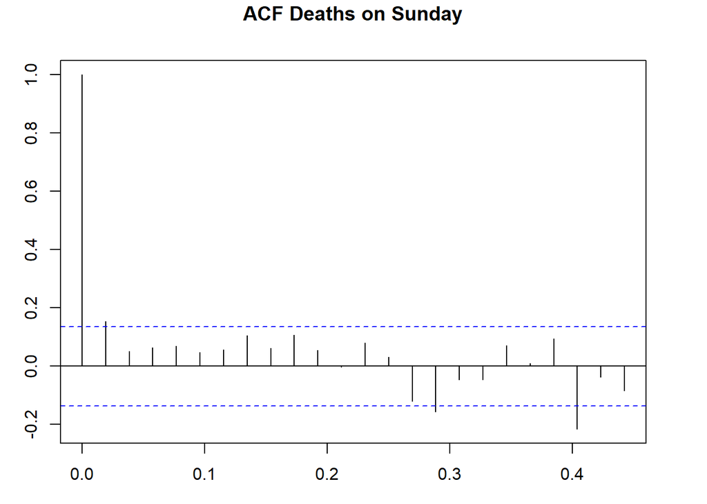

```r
acf(deaths.Sunday.ts, main = 'ACF Deaths on Sunday')
```

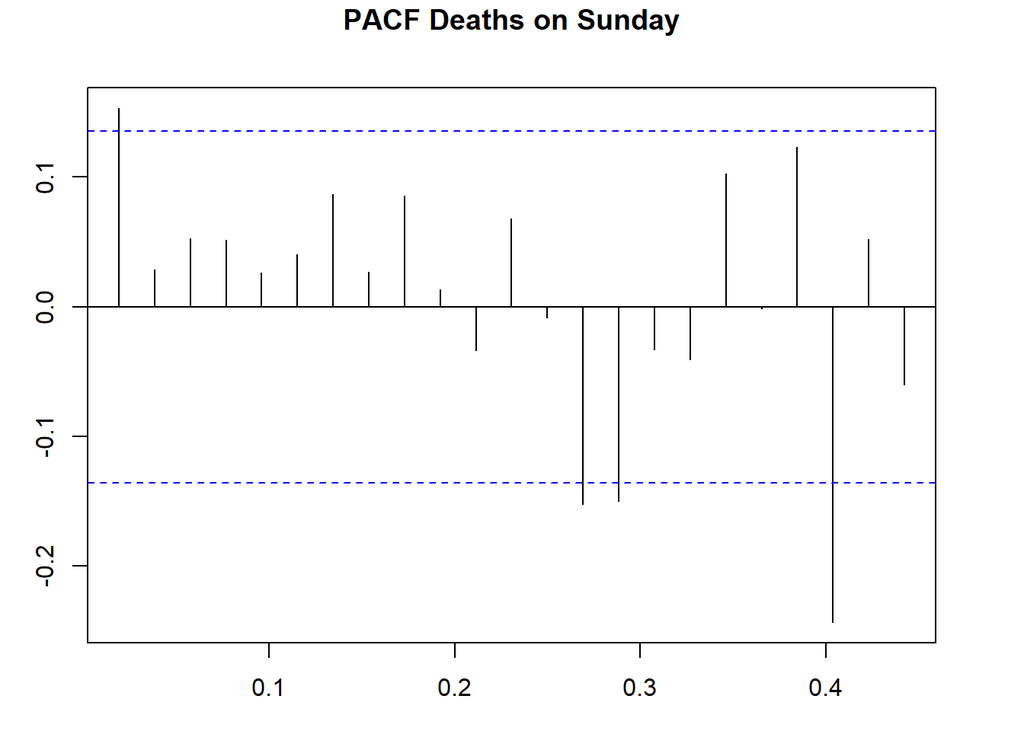

```r
pacf(deaths.Sunday.ts, main = 'PACF Deaths on Sunday')
```

# **Exercise 2:**

**Plot the relative frequencies of the marginal distribution of the time series**

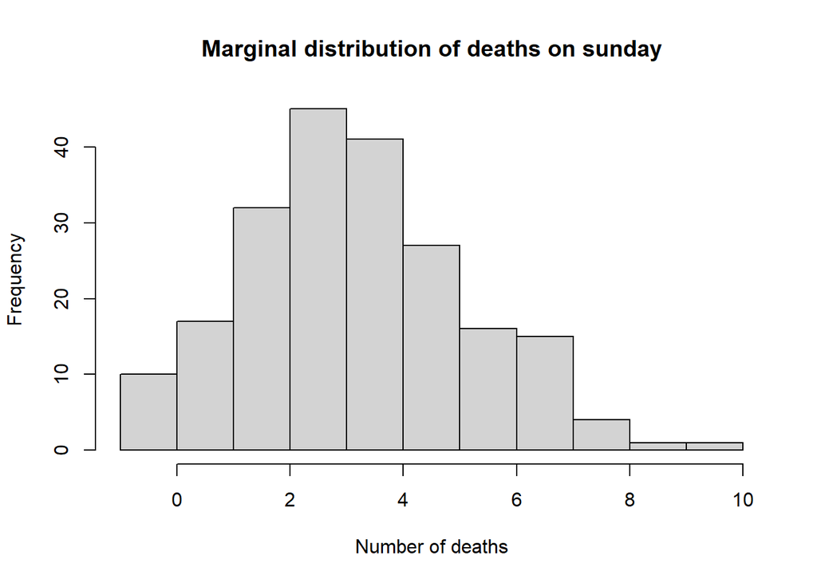

```r
#Marginal distribution

hist(deaths.Sunday.ts-0.5, main="Marginal distribution of deaths on sunday", xlab = "Number of deaths")
```

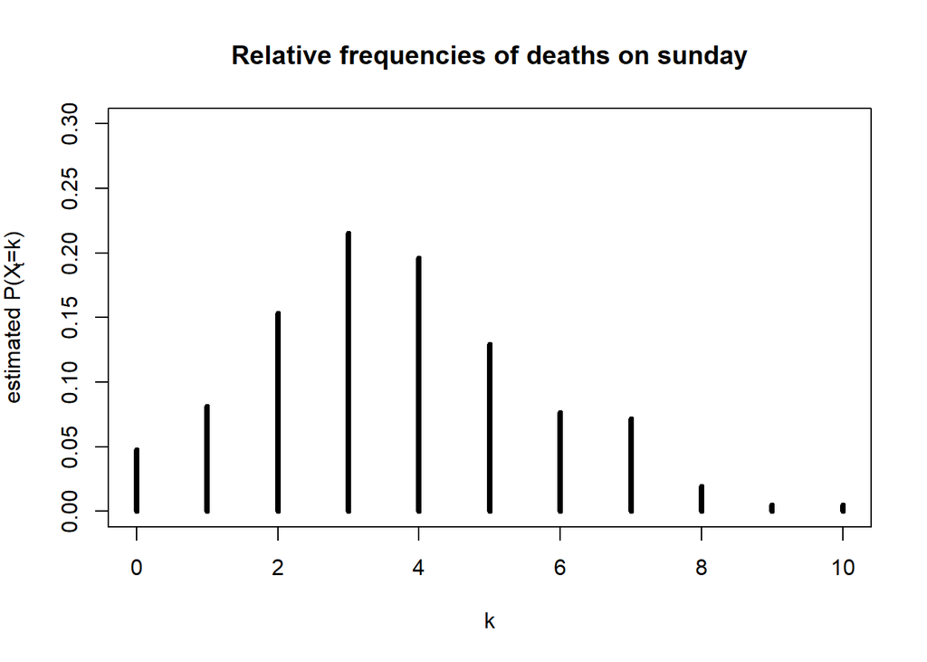

```r
#Relative frequencies

absFreq = tabulate(deaths.Sunday.ts+1)
maxVal = max(deaths.Sunday.ts)
totalLen = length(deaths.Sunday.ts)
plot(0:maxVal, absFreq/totalLen, type="h", xlab = "k", ylab = expression(paste("estimated P(X"[t],"=k)")), lwd=4, ylim=c(0,0.3), main="Relative frequencies of deaths on sunday")
```

# **Exercise 3:**

```r
#Mean

print("The observations' mean is:")
```

```
## [1] "The observations' mean is:"
```

```r
mean = mean(deaths.Sunday.ts)
mean
```

```
## [1] 3.669856
```

```r
#Variance

print("The observations' variance is:")
```

```
## [1] "The observations' variance is:"
```

```r
var = var(deaths.Sunday.ts)
var
```

```
## [1] 3.91452
```

# **Exercise 4:**

```r
#Index of Dispersion

print("The Index of Dispersion is:")
```

```
## [1] "The Index of Dispersion is:"
```

```r
ID = (totalLen-1)/totalLen*var/mean
ID
```

```
## [1] 1.061565
```

```r
#95% confidence interval for the ID

rho1 = acf(deaths.Sunday.ts, plot=FALSE)[[1]][2]

sdID = sqrt(2/totalLen*(1+rho1^2)/(1-rho1^2))

print("The 95% confidence interval for the ID is:")
```

```
## [1] "The 95% confidence interval for the ID is:"
```

```r
ID + -1/totalLen*(1+rho1)/(1-rho1) + c(-1,1)*qnorm(0.975)*sdID
```

```
## [1] 0.8587609 1.2513351
```

El valor 1 pertence al intevalo entre 0.8587609 and 1.2513351, así que no podemos rechazar la hipotesis nula de equidispersión, concluyendo que los datos presentan equidispersión.

# **Exercise 5:**

**Fit the INAR(1) model to the time series:**

- **Maximum likelihood estimation of the Poisson INAR(1) model?**

```r
#Transition probabilities of Poisson INAR(1) model:
tppois = function(k,l,lambda,alpha){
    tp = 0
    for(j in c(0:min(k,l))){
        tp = tp + dbinom(j,l,alpha)*dpois(k-j,lambda)
    }
tp
}

#Log-likelihood of Poisson INAR(1) model:
llpinar1 = function(par,data){
  T = length(data)
  value = -log(dpois(data[1], par[1]/(1-par[2])))
  for(t in c(2:T)) {
      value = value-log(tppois(data[t], data[t-1], par[1], par[2]))
  }
value
}

#Innovations' mean
mue = mean*(1-rho1)

#Poisson INAR1
estml = suppressWarnings(optim(c(mue,rho1), llpinar1, method="L-BFGS-B", lower=c(0.0001,0.0001), upper=c(9999,0.9999), control=list(ndeps=c(1e-4,1e-4)), data=deaths.Sunday.ts, hessian=TRUE))

estml
```

```
## $par
## [1] 3.1462443 0.1429882
##
## $value
## [1] 433.1827
##
## $counts
## function gradient
##        7        7
##
## $convergence
## [1] 0
##
## $message
## [1] "CONVERGENCE: REL_REDUCTION_OF_F <= FACTR*EPSMCH"
##
## $hessian
##          [,1]     [,2]
## [1,]  58.5195 205.7821
## [2,] 205.7821 972.1240
```

```r
ofiest = estml$hessian
neglmax = estml$value
estcov = solve(ofiest)
```

- **Estimates:** λ̂ λ^**,** α̂ α^**?**

  ```r
  print("The lambda estimate is:")
  ```

  ```
  ## [1] "The lambda estimate is:"
  ```

  ```r
  lambdaestml = estml$par[[1]]
  lambdaestml
  ```

  ```
  ## [1] 3.146244
  ```

  ```r
  print("The alpha estimate is:")
  ```

  ```
  ## [1] "The alpha estimate is:"
  ```

  ```r
  alphaestml = estml$par[[2]]
  alphaestml
  ```

  ```
  ## [1] 0.1429882
  ```

- **Observations’ Poisson parameter?**

  ```r
  print("The Observations’ Poisson parameter is:")
  ```

  ```
  ## [1] "The Observations’ Poisson parameter is:"
  ```

  ```r
  muestml = lambdaestml/(1-alphaestml)
  muestml
  ```

  ```
  ## [1] 3.67118
  ```

# **Exercise 6:**

**Compare the observed relative frequencies with the corresponding probabilities of a Poisson distribution with parameter equal to the estimated one.**

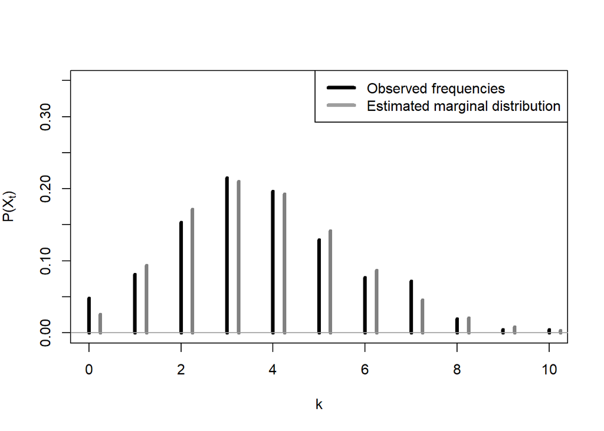

```r
plot(0:maxVal,absFreq/totalLen, type="h", xlab = "k", ylab = expression(paste("P(X"[t],")")), lwd=4, ylim=c(0,0.35))

points((0:maxVal)+.25,dpois(0:maxVal,lambda =muestml ), type="h", lwd=4, col=gray(0.5))

abline(h=0,col=8)
legend("topright",c("Observed frequencies","Estimated marginal distribution"), col=c(1,8),lwd=4,lty=1)
```

Las distribuciones son muy parecidas sugiriendo que la suposición de la distribución de Poisson es adecuada.

# **Exercise 7:**

**Compute the Pearson residuals:**

$$e_t = \frac{x_t -
\mathbb{E}(X_t|X_{t-1})}{\sqrt{\text{Var}(X_t|X_{t-1})}}, \, t=2,\ldots,
T.$$

**Plot the fitted values over the observed time series. In a different graphc, plot the Pearson residuals.**

```r
cMeanP <- function(l,lambda,alpha){
    alpha*l+lambda
}

cVarP <- function(l,lambda,alpha){
    alpha*(1-alpha)*l+lambda
}
```

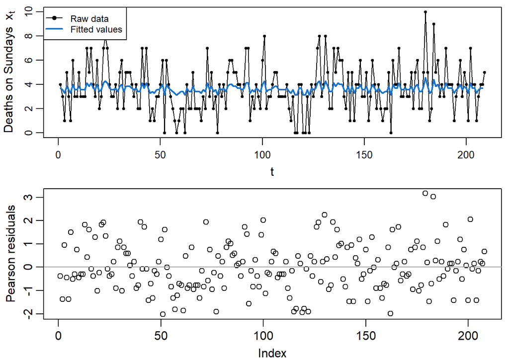

```r
res = (deaths.Sunday.ts[2:totalLen]-cMeanP(deaths.Sunday.ts[1:(totalLen-1)], lambdaestml,alphaestml)) /
  sqrt(cVarP(deaths.Sunday.ts[1:(totalLen-1)], lambdaestml,alphaestml))

par(mar=c(3, 3, 0.5, 0.5), mgp=c(1.8, 0.6, 0))
par(mfrow=c(2,1))

plot(deaths.Sunday, type="l", xlab = "t", ylab = expression("Deaths on Sundays  x "[t]), cex.axis=0.85);points(deaths.Sunday, pch=19, cex=0.5);lines(cMeanP(deaths.Sunday[1:(totalLen-1)], lambdaestml,alphaestml),col=4,lwd=2);legend("topleft",c("Raw data","Fitted values"),col=c(1,4),lwd=c(1,2),pch=c(19,NA),cex=.75)

plot(res, ylab = "Pearson residuals")
abline(h=0,col=8)
```

# **Exercise 8:**

**Plot the ACF and the PACF of the Pearson residuals. Plot the Probability integral transform (PIT). Do you think the the INAR(1) model is appropriate for this time series.**

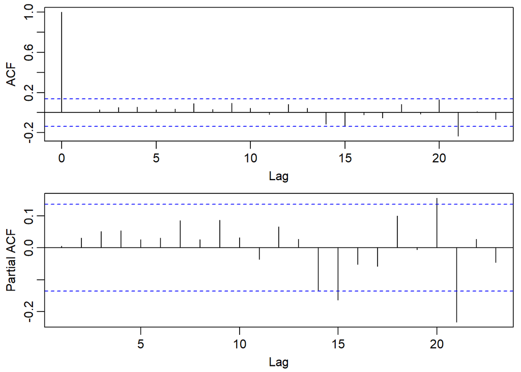

```r
par(mar=c(3, 3, 0.5, 0.5), mgp=c(1.8, 0.6, 0))
par(mfrow=c(2,1))
acf(res, main = 'Pearson residuals')
pacf(res, main = 'Pearson residuals')
```

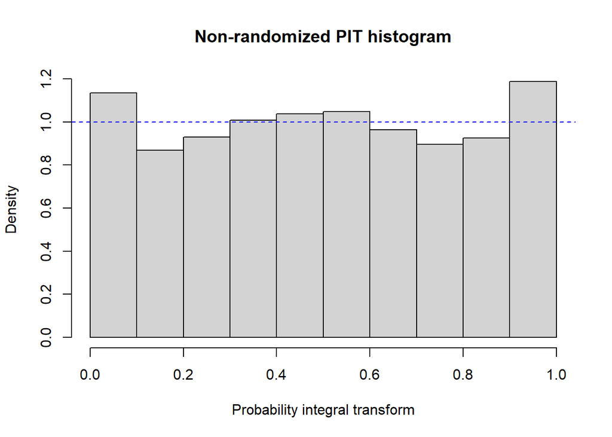

```r
deaths_sundays_pois_1 = tsglm(deaths.Sunday,
                          model = list(past_obs=c(1)),
                          link="log", distr="poisson")
pit(deaths_sundays_pois_1)
```

De igual manera, observando el gráfico de la serie temporal se observa estacinariedad y solo se tiene valores enteros positvos, pudiendo concluir que el modelo INAR(1) es adecuado para esta serie temporal.

# **Exercise 9:**

**Fit a Generalized Linear Models for the time series using the function `tsglm`. Use lags 1 and 52 for the observations and for the mean. Use the logarithm as the link function.**

```r
deaths_sundays_pois <- tsglm(deaths.Sunday.ts,
                          model=list(past_obs=c(1,52)),
                          link="log", distr="poisson")
summary(deaths_sundays_pois)
```

```
##
## Call:
## tsglm(ts = deaths.Sunday.ts, model = list(past_obs = c(1, 52)),
##     link = "log", distr = "poisson")
##
## Coefficients:
##              Estimate  Std.Error  CI(lower)  CI(upper)
## (Intercept)    0.9889     0.1588   0.677734      1.300
## beta_1         0.1466     0.0745   0.000527      0.293
## beta_52        0.0715     0.0817  -0.088585      0.232
## Standard errors and confidence intervals (level =  95 %) obtained
## by normal approximation.
##
## Link function: log
## Distribution family: poisson
## Number of coefficients: 3
## Log-likelihood: -433.1912
## AIC: 872.3824
## BIC: 882.4094
## QIC: 872.3824
```

# **Exercise 10:**

**Fit now the log-linear model until the middle of 2017 (`end=c(2017,26)`). Then predict the number of deaths by accidents in Sundays from the middle of 2017 to the end of 2017. Finally, compare the model predictions with the true observed values.**

```r
deaths_sundays_to_2017 = window(deaths.Sunday.ts, end = c(2017,26))
deaths_sundays_from_2017 = window(deaths.Sunday.ts, start = c(2017,27))

deaths_sundays_pois_2017 <- tsglm(deaths_sundays_to_2017,
                          model=list(past_obs=c(1,52)),
                          link="log", distr="poisson")


deaths_sundays_pred_2018 <-predict(deaths_sundays_pois_2017, n.ahead = length(deaths_sundays_from_2017), level = 0.9, global = FALSE, B = 2018)

deaths_sundays_pred_2018_global <-predict(deaths_sundays_pois_2017, n.ahead = length(deaths_sundays_from_2017), level = 0.9, global = TRUE, B = 2018)
```

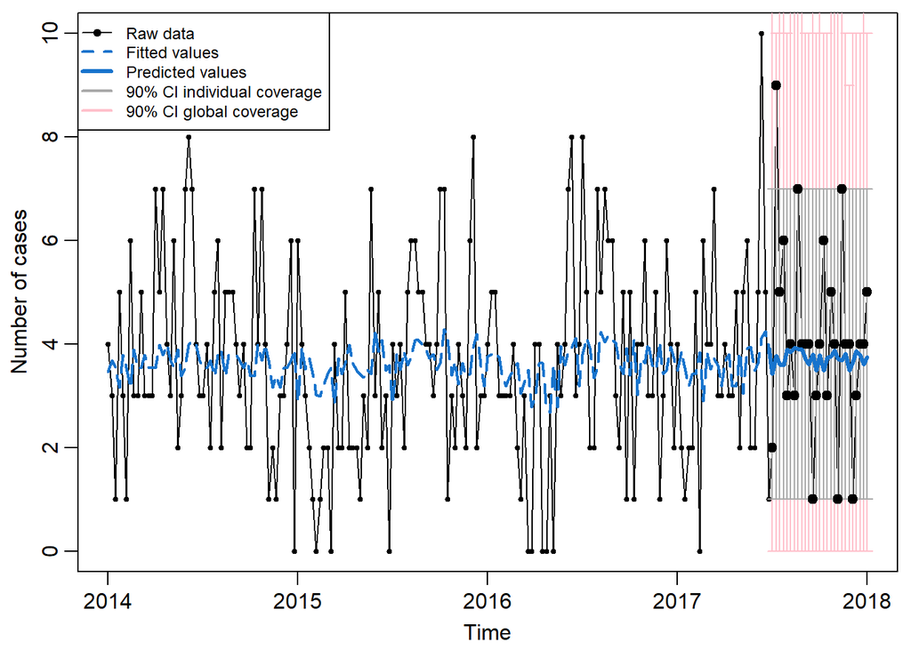

```r
par(mar=c(3, 3, 0.5, 0.5), mgp=c(1.8, 0.6, 0))

plot(deaths.Sunday.ts, ylab="Number of cases")
points(deaths.Sunday.ts,pch=19,cex=.5)

lines(fitted(deaths_sundays_pois_2017), col=4, lty = "longdash", lwd=2)

arrows(x0 = time(deaths_sundays_pred_2018_global$interval),
       y0 = deaths_sundays_pred_2018_global$interval[, "lower"],
       y1 = deaths_sundays_pred_2018_global$interval[, "upper"],
       angle = 90, code = 3, length = 0.04, col = "pink", lwd = 1)

arrows(x0 = time(deaths_sundays_pred_2018$interval),
       y0 = deaths_sundays_pred_2018$interval[, "lower"],
       y1 = deaths_sundays_pred_2018$interval[, "upper"],
       angle = 90, code = 3, length = 0.04, col = "darkgrey", lwd = 1)

points(deaths_sundays_from_2017, pch = 19)
lines(x = c(time(deaths_sundays_to_2017)[182], time(deaths_sundays_pred_2018$pred)),
      c(fitted(deaths_sundays_pois_2017)[182], deaths_sundays_pred_2018$pred),
      col = 4, lty = "solid", lwd = 3)

points(deaths_sundays_from_2017, pch = 19)
lines(x = c(time(deaths_sundays_to_2017)[182], time(deaths_sundays_pred_2018$pred)),
      c(fitted(deaths_sundays_pois_2017)[182], deaths_sundays_pred_2018$pred),
      col = 4, lty = "solid", lwd = 3)

legend("topleft",
       c("Raw data", "Fitted values", "Predicted values",
         "90% CI individual coverage", "90% CI global coverage"),
       col=c(1,4,4,"darkgrey","pink"),
       lwd=c(1,2,3,2,2),
       lty=c(1,2,1,1,1),
       pch=c(19,NA,NA,NA,NA),
       cex=.75)
```

La prediccion (en azul), se encuentra dentro de los rangos de confianza, tanto local como global, sin embargo, no coincide del todo con la tendencia del conjunto de datos reales (apartir de mediados del 2017).